# Case Study - Thera Bank: Using Logistic Regression Models for determining personal Loans Purchase

### University of Texas at Austin - Post Graduate Program in AI and Machine Learning

## Introduction

This case study is designed to use supervised Machine Learning in order to determine likelihood of purchase of credit products by a bank.

The dataset comprises of data on 5000 customers, mainly relationship with the bank and purchase of products and also response to last loan campaign conducted by the bank.

## 1. Loading the necessary packages

```python
import pandas as pd
from pandas_profiling import ProfileReport
import numpy as np
import matplotlib.pyplot as plt
from bokeh.plotting import figure, show
from bokeh.io import output_notebook
from sklearn.model_selection import train_test_split
from sklearn.linear_model import LogisticRegression
import seaborn as sns
sns.set(style="white")
sns.set(style="whitegrid", color_codes=True)
%matplotlib inline
```

## 1.1. Load the dataset

```python
df = pd.read_csv('Bank_Personal_Loan_Modelling.csv')
df.head(20)
```

|  | ID | Age | Experience | Income | ZIP Code | Family | CCAvg | Education | Mortgage | Personal Loan | Securities Account | CD Account | Online | CreditCard |
| --- | --- | --- | --- | --- | --- | --- | --- | --- | --- | --- | --- | --- | --- | --- |
| 0 | 1 | 25 | 1 | 49 | 91107 | 4 | 1.6 | 1 | 0 | 0 | 1 | 0 | 0 | 0 |
| 1 | 2 | 45 | 19 | 34 | 90089 | 3 | 1.5 | 1 | 0 | 0 | 1 | 0 | 0 | 0 |
| 2 | 3 | 39 | 15 | 11 | 94720 | 1 | 1.0 | 1 | 0 | 0 | 0 | 0 | 0 | 0 |
| 3 | 4 | 35 | 9 | 100 | 94112 | 1 | 2.7 | 2 | 0 | 0 | 0 | 0 | 0 | 0 |
| 4 | 5 | 35 | 8 | 45 | 91330 | 4 | 1.0 | 2 | 0 | 0 | 0 | 0 | 0 | 1 |
| 5 | 6 | 37 | 13 | 29 | 92121 | 4 | 0.4 | 2 | 155 | 0 | 0 | 0 | 1 | 0 |
| 6 | 7 | 53 | 27 | 72 | 91711 | 2 | 1.5 | 2 | 0 | 0 | 0 | 0 | 1 | 0 |
| 7 | 8 | 50 | 24 | 22 | 93943 | 1 | 0.3 | 3 | 0 | 0 | 0 | 0 | 0 | 1 |
| 8 | 9 | 35 | 10 | 81 | 90089 | 3 | 0.6 | 2 | 104 | 0 | 0 | 0 | 1 | 0 |
| 9 | 10 | 34 | 9 | 180 | 93023 | 1 | 8.9 | 3 | 0 | 1 | 0 | 0 | 0 | 0 |
| 10 | 11 | 65 | 39 | 105 | 94710 | 4 | 2.4 | 3 | 0 | 0 | 0 | 0 | 0 | 0 |
| 11 | 12 | 29 | 5 | 45 | 90277 | 3 | 0.1 | 2 | 0 | 0 | 0 | 0 | 1 | 0 |
| 12 | 13 | 48 | 23 | 114 | 93106 | 2 | 3.8 | 3 | 0 | 0 | 1 | 0 | 0 | 0 |
| 13 | 14 | 59 | 32 | 40 | 94920 | 4 | 2.5 | 2 | 0 | 0 | 0 | 0 | 1 | 0 |
| 14 | 15 | 67 | 41 | 112 | 91741 | 1 | 2.0 | 1 | 0 | 0 | 1 | 0 | 0 | 0 |
| 15 | 16 | 60 | 30 | 22 | 95054 | 1 | 1.5 | 3 | 0 | 0 | 0 | 0 | 1 | 1 |
| 16 | 17 | 38 | 14 | 130 | 95010 | 4 | 4.7 | 3 | 134 | 1 | 0 | 0 | 0 | 0 |
| 17 | 18 | 42 | 18 | 81 | 94305 | 4 | 2.4 | 1 | 0 | 0 | 0 | 0 | 0 | 0 |
| 18 | 19 | 46 | 21 | 193 | 91604 | 2 | 8.1 | 3 | 0 | 1 | 0 | 0 | 0 | 0 |
| 19 | 20 | 55 | 28 | 21 | 94720 | 1 | 0.5 | 2 | 0 | 0 | 1 | 0 | 0 | 1 |

## 1.2 Verifying main characteristics of data: summary, tail, info.

```python
# Investigating the tail of the Dataset
df.tail()
```

|  | ID | Age | Experience | Income | ZIP Code | Family | CCAvg | Education | Mortgage | Personal Loan | Securities Account | CD Account | Online | CreditCard |
| --- | --- | --- | --- | --- | --- | --- | --- | --- | --- | --- | --- | --- | --- | --- |
| 4995 | 4996 | 29 | 3 | 40 | 92697 | 1 | 1.9 | 3 | 0 | 0 | 0 | 0 | 1 | 0 |
| 4996 | 4997 | 30 | 4 | 15 | 92037 | 4 | 0.4 | 1 | 85 | 0 | 0 | 0 | 1 | 0 |
| 4997 | 4998 | 63 | 39 | 24 | 93023 | 2 | 0.3 | 3 | 0 | 0 | 0 | 0 | 0 | 0 |
| 4998 | 4999 | 65 | 40 | 49 | 90034 | 3 | 0.5 | 2 | 0 | 0 | 0 | 0 | 1 | 0 |
| 4999 | 5000 | 28 | 4 | 83 | 92612 | 3 | 0.8 | 1 | 0 | 0 | 0 | 0 | 1 | 1 |

```python
#Checking info for classifications and types of variables
df.info()
```

```
<class 'pandas.core.frame.DataFrame'>
RangeIndex: 5000 entries, 0 to 4999
Data columns (total 14 columns):
ID                    5000 non-null int64
Age                   5000 non-null int64
Experience            5000 non-null int64
Income                5000 non-null int64
ZIP_Code              5000 non-null int64
Family                5000 non-null int64
CCAvg                 5000 non-null float64
Education             5000 non-null int64
Mortgage              5000 non-null int64
Personal_Loan         5000 non-null int64
Securities_Account    5000 non-null int64
CD_Account            5000 non-null int64
Online                5000 non-null int64
CreditCard            5000 non-null int64
dtypes: float64(1), int64(13)
memory usage: 547.0 KB
```

## 2. EDA Analysis using Pandas Profiling

The package pandas_profiling generates a full report on the dataset, regarding what are the main correlations, the distribution of each variable, etc.

Since it is a very powerful and simplifying tool for data analysis, it will be used for this task.

```python
# Being like the cool kids: using pandas_profiling for a full EDA report.
profile = ProfileReport(df, title='Thera Bank Dataset Profile',
                        html={'style':{'full_width':True}})
profile.to_notebook_iframe()
```

[interactive chart not shown]

### 2.1. number of unique counts in each column

#### Unique values for each column - Distinct Counts on Variables Section

In Pandas report, under 'Variables', it is possible to find the full list of distinct counts (unique values) for each column.

### 2.2. How many people have zero mortgage?

```python
Zero_Mortgage = df.groupby(df.Mortgage == 0)
Zero_Mortgage.count()
```

| Mortgage | ID | Age | Experience | Income | ZIP_Code | Family | CCAvg | Education | Mortgage | Personal_Loan | Securities_Account | CD_Account | Online | CreditCard |
| --- | --- | --- | --- | --- | --- | --- | --- | --- | --- | --- | --- | --- | --- | --- |
| False | 1538 | 1538 | 1538 | 1538 | 1538 | 1538 | 1538 | 1538 | 1538 | 1538 | 1538 | 1538 | 1538 | 1538 |
| True | 3462 | 3462 | 3462 | 3462 | 3462 | 3462 | 3462 | 3462 | 3462 | 3462 | 3462 | 3462 | 3462 | 3462 |

```python
ZeroCC = df.groupby(df.CreditCard == 0)
ZeroCC.count()
```

| CreditCard | ID | Age | Experience | Income | ZIP_Code | Family | CCAvg | Education | Mortgage | Personal_Loan | Securities_Account | CD_Account | Online | CreditCard |
| --- | --- | --- | --- | --- | --- | --- | --- | --- | --- | --- | --- | --- | --- | --- |
| False | 1470 | 1470 | 1470 | 1470 | 1470 | 1470 | 1470 | 1470 | 1470 | 1470 | 1470 | 1470 | 1470 | 1470 |
| True | 3530 | 3530 | 3530 | 3530 | 3530 | 3530 | 3530 | 3530 | 3530 | 3530 | 3530 | 3530 | 3530 | 3530 |

### 2.4: Value Counts for all variables

```python
#Describing variables for better understanding
df.describe()
```

|  | ID | Age | Experience | Income | ZIP Code | Family | CCAvg | Education | Mortgage | Personal Loan | Securities Account | CD Account | Online | CreditCard |
| --- | --- | --- | --- | --- | --- | --- | --- | --- | --- | --- | --- | --- | --- | --- |
| count | 5000.000000 | 5000.000000 | 5000.000000 | 5000.000000 | 5000.000000 | 5000.000000 | 5000.000000 | 5000.000000 | 5000.000000 | 5000.000000 | 5000.000000 | 5000.00000 | 5000.000000 | 5000.000000 |
| mean | 2500.500000 | 45.338400 | 20.104600 | 73.774200 | 93152.503000 | 2.396400 | 1.937938 | 1.881000 | 56.498800 | 0.096000 | 0.104400 | 0.06040 | 0.596800 | 0.294000 |
| std | 1443.520003 | 11.463166 | 11.467954 | 46.033729 | 2121.852197 | 1.147663 | 1.747659 | 0.839869 | 101.713802 | 0.294621 | 0.305809 | 0.23825 | 0.490589 | 0.455637 |
| min | 1.000000 | 23.000000 | -3.000000 | 8.000000 | 9307.000000 | 1.000000 | 0.000000 | 1.000000 | 0.000000 | 0.000000 | 0.000000 | 0.00000 | 0.000000 | 0.000000 |
| 25% | 1250.750000 | 35.000000 | 10.000000 | 39.000000 | 91911.000000 | 1.000000 | 0.700000 | 1.000000 | 0.000000 | 0.000000 | 0.000000 | 0.00000 | 0.000000 | 0.000000 |
| 50% | 2500.500000 | 45.000000 | 20.000000 | 64.000000 | 93437.000000 | 2.000000 | 1.500000 | 2.000000 | 0.000000 | 0.000000 | 0.000000 | 0.00000 | 1.000000 | 0.000000 |
| 75% | 3750.250000 | 55.000000 | 30.000000 | 98.000000 | 94608.000000 | 3.000000 | 2.500000 | 3.000000 | 101.000000 | 0.000000 | 0.000000 | 0.00000 | 1.000000 | 1.000000 |
| max | 5000.000000 | 67.000000 | 43.000000 | 224.000000 | 96651.000000 | 4.000000 | 10.000000 | 3.000000 | 635.000000 | 1.000000 | 1.000000 | 1.00000 | 1.000000 | 1.000000 |

### 2.5: Understanding categorical values

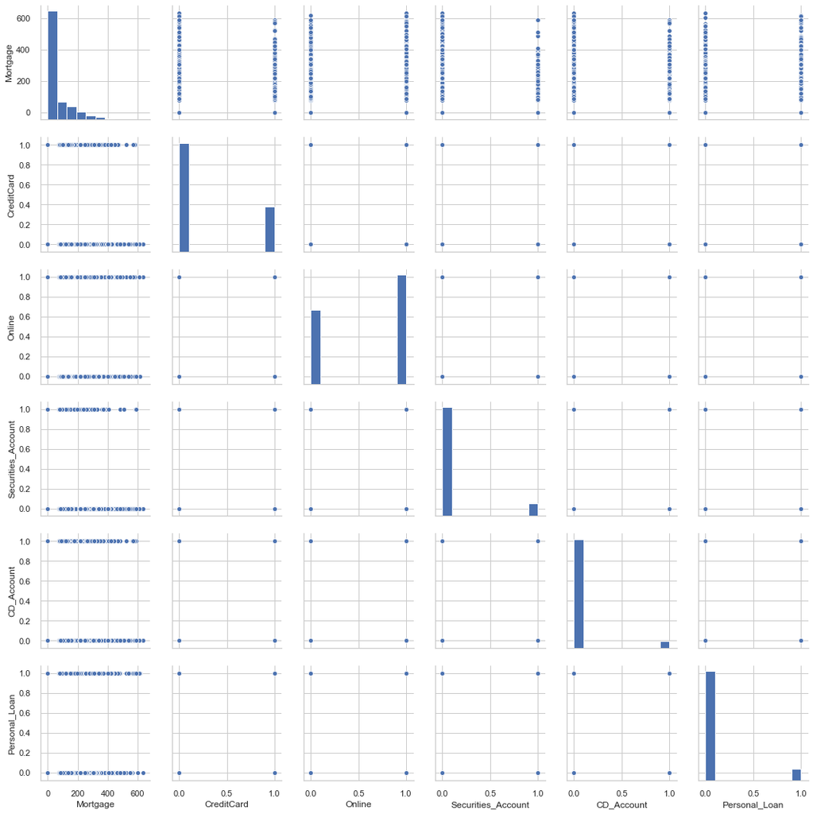

```python
Product = df[['Mortgage', 'CreditCard', 'Online', 'Securities_Account', 'CD_Account', 'Personal_Loan']]
sns.pairplot(Product)
```

### 2.6 Understanding Correlations

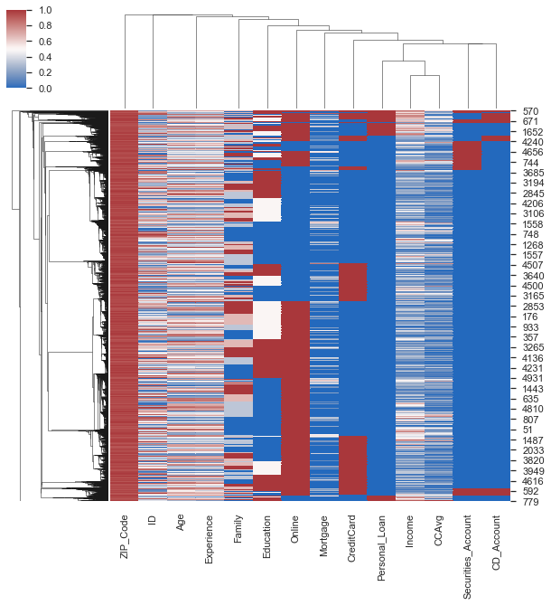

```python
#Let's do a clustermap to see if anything can be learned:
plt.figure( figsize = (25,25))
sns.clustermap(df, metric="correlation", method="single", cmap="vlag", standard_scale = 1)
```

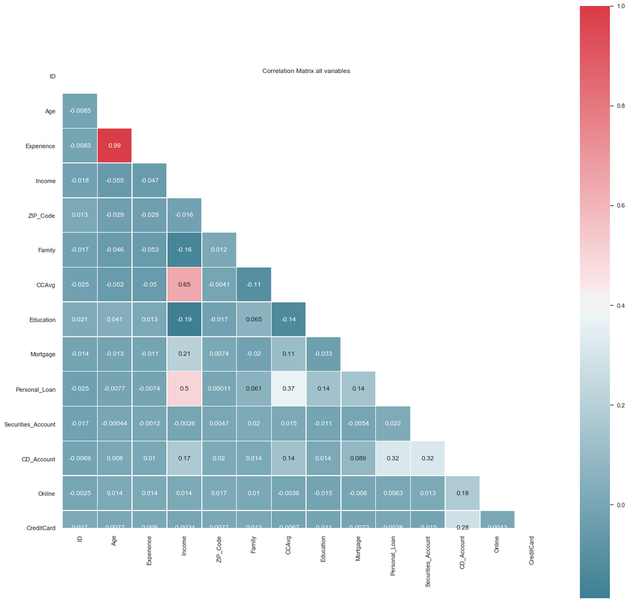

```python
#Creating a correlation matrix (one-sided) to confirm correlations presented on pandas profiling:
plt.figure( figsize = (20,20))
corr = df.corr()
mask = np.triu(np.ones_like(corr, dtype=np.bool))
cmap = sns.diverging_palette(220, 10, as_cmap = True)
plt.title('Correlation Matrix all variables')
sns.heatmap(corr, cmap = cmap,  square = True, linewidth = .5, annot = True, mask = mask)
```

I'll leave as it is, since, fortunately, the most relevant values are being plotted and evident.

To check this issue, it is here: https://github.com/mwaskom/seaborn/issues/1773

## 3. Preparing the Dataset: train_test_split

Here the objective is to separate the Dataset into two partitions:

Train - Where the algorithm should learn how to predict outcomes from the model. Test - Where we will test the results and compare to real data and verify the fit.

#### Creating an object of feature columns = where will the model learn from

In here and from the first model, we are to insert every single column from the dataset, with the exception of ID (we know it is a 100% unique column with the EDA, does not make sense to insert it) and Personal Loan, for us not to predict something on itself.

```python
feature_cols = ['Age', 'Experience', 'Income', 'ZIP_Code',
                    'Family', 'CCAvg', 'Education', 'Mortgage',
                    'Securities_Account', 'CD_Account', 'Online', 'CreditCard']
```

Let's then call X the subset with the feature columns

```python
X = df[feature_cols]
y = df['Personal_Loan']
```

Then, I will create the train and test sets using train_test_split, using a 70/30 division for the dataset and creating a random state for replication purposes.

The number is 42 just as an homage to the ultimate question to life, the universe and everything; and it is quite easy to remember.

```python
X_train, X_test, y_train, y_test = train_test_split(X, y, test_size = 0.3, random_state=42)
```

```python
#checking the train set.
X_train.shape
```

```
(3500, 12)
```

```python
#checking target variable train.
y_train.shape
```

```
(3500,)
```

```python
#checking test set.
X_test.shape
```

```
(1500, 12)
```

```python
#checking test target variable
y_test.shape
```

```
(1500,)
```

## 4. Creating the LogReg

```python
#step one: create the model using sklearn.linear_model: LogisticRegression
model = LogisticRegression()
#step two: fit the model into train set
model.fit(X_train, y_train)
```

```
LogisticRegression(C=1.0, class_weight=None, dual=False, fit_intercept=True,
                   intercept_scaling=1, l1_ratio=None, max_iter=100,
                   multi_class='warn', n_jobs=None, penalty='l2',
                   random_state=None, solver='warn', tol=0.0001, verbose=0,
                   warm_start=False)
```

```python
# Step three: predict model to test set.
y_pred = model.predict(X_test)
```

```python
#Step Four: check model with confusion matrix
from sklearn import metrics
cnf_matrix = metrics.confusion_matrix(y_test, y_pred)
cnf_matrix
```

```
array([[1303,   40],
       [ 107,   50]])
```

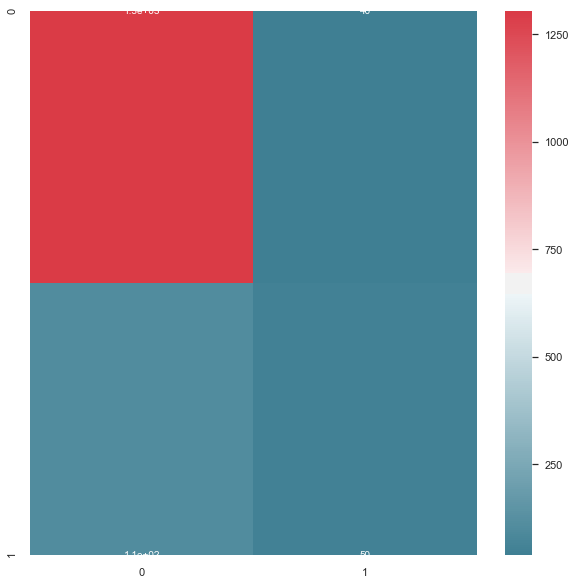

```python
#Visualizing confusion matrix.
plt.figure( figsize = (10,10))
sns.heatmap(cnf_matrix, annot = True, cmap = cmap)
```

```python
# Verifying Accuracy, Precision and Recall of the Model
print("Accuracy:",metrics.accuracy_score(y_test, y_pred))
print("Precision:",metrics.precision_score(y_test, y_pred))
print("Recall:",metrics.recall_score(y_test, y_pred))
```

```
Accuracy: 0.902
Precision: 0.5555555555555556
Recall: 0.3184713375796178
```

[figure not shown]

```python
# Plotting the AUC
plt.figure( figsize = (20,10))
y_pred_proba = logreg.predict_proba(X_test)[::,1]
fpr, tpr, _ = metrics.roc_curve(y_test,  y_pred_proba)
auc = metrics.roc_auc_score(y_test, y_pred_proba)
plt.title('AUC LogReg')
plt.plot(fpr,tpr,label="data 1, auc="+str(auc))
plt.legend(loc=4)
plt.show()
```

## 5. How can we improve the model simply - A second Attempt by removing variables.

From the correlation matrix, we can verify that some of the columns do not seem to contribute to the model at all, such as ZIP code, Age and Experience.

Let's try the model again without those.

I am simply using the very same code with a few changes regarding feature_cols.

```python
feature_cols2 = [ 'Income',
                    'Family', 'CCAvg', 'Education', 'Mortgage',
                    'Securities_Account', 'CD_Account', 'Online', 'CreditCard']
X2 = df[feature_cols2]
y = df['Personal_Loan']
X_train, X_test, y_train, y_test = train_test_split(X2, y, test_size = 0.3, random_state=42)
#step two: fit the model into train set
model.fit(X_train, y_train)
# Step three: predict model to test set.
y_pred = model.predict(X_test)
cnf_matrix = metrics.confusion_matrix(y_test, y_pred)
cnf_matrix
```

```
array([[1329,   14],
       [  65,   92]])
```

```python
# Verifying Accuracy, Precision and Recall of the Model
print("Accuracy:",metrics.accuracy_score(y_test, y_pred))
print("Precision:",metrics.precision_score(y_test, y_pred))
print("Recall:",metrics.recall_score(y_test, y_pred))
```

```
Accuracy: 0.9473333333333334
Precision: 0.8679245283018868
Recall: 0.5859872611464968
```

### All indicators have improved, with precision going from 0.55 in the first model to 0.86 in this second, leaner model.

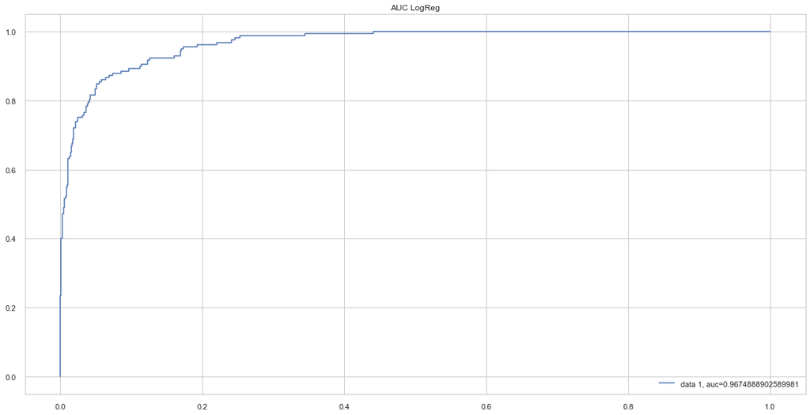

```python
# Plotting the AUC
plt.figure( figsize = (20,10))
y_pred_proba = model.predict_proba(X_test)[::,1]
fpr, tpr, _ = metrics.roc_curve(y_test,  y_pred_proba)
auc = metrics.roc_auc_score(y_test, y_pred_proba)
plt.title('AUC LogReg')
plt.plot(fpr,tpr,label="data 1, auc="+str(auc))
plt.legend(loc=4)
plt.show()
```

#### AUC has also moved from 0.922 to 0.967, showing that the leaner model is better.

# 6. Conclusion

According to the whole analysis on of the Dataset, it comes to a conclusion that it is quite possible to predict with a very good degree of certainty the type of client that is prone to hiring a Personal Loan: people who have hired other products and services from the bank, of higher income and that have higher average spending on Credit Card.

Whereas, variables such as age or experience seem not to count as much, in contrary to what we would expect, and therefore add to a model based on judgement.

Of course, a 0.90 accuracy for a model is not, by all means, bad; However, 0.95 (rounded) is significantly better, which in turn, can save a lot of money in terms of sales expenses and overall effort.

Thus, by creating a method that is more precise and by understanding possible "triggers" of what is credit acquiring behavior, Theras Bank can focus on approaching personal credit to services of higher likelihood of combined use, such as credit cards.

From the results, it seems that a very "plain vanilla" model such as Logistic Regression can be incredibly powerful in predicting outcomes such as these. While other more sophisticated models can be attempted, the straightforwardness of this method qualifies it for a very good standard model for first attempt by the bank and these values becoming the standard precision required of other models to surpass in order to be considered.